# Assignment 2

Alireza

2023-10-30

**Part 1**

```r
store_table <-
  data.frame(key=c("Bank", "Younge", "Papineau", "Boundary", "Bertrand"),
             Street=c("Bank St", "Younge St", "Rue Papineau", "Boundray Road", "Rue Bertrand"),
             city=c("OT", "TR", "Mo", "Va", "QU"))

city_info <-
  data.frame(
    city=c("OT", "TR", "MO", "VA", "QU"),
    name=c("Ottawa", "Toronto", "Montreal", "Vancouver", "Quebec City"),
    country=c("Canada", "Canada", "Canada", "Canada", "Canada")
  )

date_table <-
  data.frame(key=1:12,
             month=c(1, 2, 3, 4, 5, 6, 7, 8, 9, 10, 11, 12),
             quarter=c("Q1","Q1","Q1","Q2","Q2","Q2","Q3","Q3","Q3","Q4","Q4","Q4"),
             year=c(2022, 2023))

key=c("personal", "small", "medium", "large", "xlarge")
size_table <-data.frame(key=factor(x=key,levels=c("personal", "small", "medium", "large", "xlarge"),
                                   ordered=TRUE),
                        price =c(7, 9, 11, 13, 15))

dough_table <-
  data.frame(key=c("thin", "regular", "stuffed crust"))

cheese_table <-
  data.frame(key=c("mozzarella", "cheddar", "Goda"))

topping_table <-
  data.frame(key=c("Pepperoni", "Tomato", "Bacon", "mushroom"))

gen_orders <- function (no_recs) {
  OrderID <- 1:no_recs
  store <- sample(store_table$key, no_recs, replace = TRUE)
  time_year <- sample(c(2022, 2023), no_recs, replace = TRUE, prob = c(1, 1.7))
  time_month <- sample(date_table$month, no_recs, replace = TRUE, prob = c(1, 1, 1, 1, 1, 1,
                                                                           1, 1, 1, 1, 1, 1))
  size <- sample(size_table$key, no_recs, replace = TRUE, prob = c(1, 1, 1, 1.5, 2))
  dough <- sample(dough_table$key, no_recs, replace = TRUE)
  cheese <- sample(cheese_table$key, no_recs, replace = TRUE)
  topping <- sample(topping_table$key, no_recs, replace = TRUE)
  quantity <- sample(1:5, no_recs, replace = TRUE, prob = c(5, 2, 1, 1, 1))
  profit <- quantity*size_table[size, ]$price

  orders <- data.frame(month=time_month,
                      year=time_year,
                      loc=store,
                      size=size,
                      dough=dough,
                      cheese=cheese,
                      topping=topping,
                      quantity=quantity,
                      profit=profit)

  # Sort the records by time order
  orders <- orders[order(orders$year, orders$month),]
  row.names(orders) <- NULL
  return(orders)

}

orders_fact <- gen_orders(1000)
head(orders_fact)
```

```
##   month year      loc   size         dough     cheese   topping quantity profit
## 1     1 2022 Boundary xlarge stuffed crust       Goda    Tomato        1     15
## 2     1 2022 Papineau xlarge          thin       Goda Pepperoni        1     15
## 3     1 2022     Bank xlarge stuffed crust mozzarella     Bacon        2     30
## 4     1 2022   Younge  large       regular mozzarella Pepperoni        1     13
## 5     1 2022   Younge medium          thin       Goda  mushroom        1     11
## 6     1 2022     Bank  small       regular       Goda  mushroom        5     45
```

```r
write.csv(store_table, "store_location.csv", row.names = FALSE)
write.csv(city_info, "city_info.csv", row.names = FALSE)
write.csv(size_table, "pizza_size.csv", row.names = FALSE)
write.csv(dough_table, "dough.csv", row.names = FALSE)
write.csv(cheese_table, "cheese_type.csv", row.names = FALSE)
write.csv(topping_table, "topping.csv", row.names = FALSE)
write.csv(orders_fact, "orders.csv", row.names = FALSE)
```

**2-** In this section, OLAP cube got created and named revenue_cube.

```r
revenue_cube <-
    tapply(orders_fact$profit,
           orders_fact[,c("size", "month", "year", "loc")],
           function(x){return(sum(x))})

revenue_cube
```

```
## , , year = 2022, loc = Bank
##
##           month
## size        1  2   3  4  5  6  7   8   9 10 11 12
##   personal NA NA  28 14  7 28  7  NA  NA 14 NA  7
##   small    54 NA  18 NA  9 NA 27  54  18 54 54 45
##   medium   NA NA  11 NA 11 NA 11  NA  55 NA NA NA
##   large    NA NA  NA 13 39 52 13 130  65 78 78 39
##   xlarge   30 60 105 60 60 90 60  45 105 45 NA 75
##
## , , year = 2023, loc = Bank
##
##           month
## size         1   2   3  4   5   6  7   8   9  10 11  12
##   personal  NA  35  28  7  77   7 28  NA  35  NA 21   7
##   small      9  99  18 NA  NA  27 NA  54  18  27 27  18
##   medium    33 110  66 99  22  NA NA  22  11  88 11  44
##   large     65  78  39 26 104  65 26 104 104  13 65  39
##   xlarge   180 225 360 30  75 210 15  90 150 150 90 150
##
## , , year = 2022, loc = Bertrand
##
##           month
## size        1  2  3  4  5  6  7  8   9 10 11 12
##   personal NA NA NA 14  7 28 28 14  NA 91 NA 14
##   small    NA 18  9 NA  9  9 NA NA  NA NA 18 NA
##   medium   NA 11 44 11 11 11 22 NA  NA 22 44 88
##   large    NA 13 NA 39 78 52 52 NA  13 65 26 26
##   xlarge   90 15 NA 15 30 15 15 30 150 90 75 15
##
## , , year = 2023, loc = Bertrand
##
##           month
## size        1  2   3  4   5   6   7  8  9 10  11  12
##   personal  7 28  21 NA  NA  21  49 21 21  7  49  21
##   small    NA 54  18 NA  18  72  27 27 18 45  18  18
##   medium   11 44  22 33  NA  NA  88 88 88 11  66  NA
##   large    39 52  13 13 117  NA  91 13 NA 13  39  13
##   xlarge   75 30 285 90 225 300 120 75 60 60 135 180
##
```

[output cut: 44 more lines]

```
##   personal  NA  NA NA 21 21 49 NA 21  NA  14  7 NA
##   small     90  NA 27 36 27  9  9 72  45  NA NA NA
##   medium    44  NA 33 NA NA 11 22 NA  44  66 44 NA
##   large    104  65 39 52 NA 52 65 65 143  26 39 NA
##   xlarge    NA 120 45 45 NA NA NA 45  45 165 30 NA
##
## , , year = 2023, loc = Younge
##
##           month
## size         1   2   3  4   5   6   7   8   9  10  11  12
##   personal  35  21  NA 56   7  14  70  35  56   7  63  35
##   small     27  NA  90 18  45  90  54  27  45  NA  18  18
##   medium    NA  NA  55 11  NA  44  55  33  NA 121  55  44
##   large     52  78  13 26 143  91 156  26  78  91  NA  13
##   xlarge   105 135 135 75 135 120 315 105 120  90 135 105
```

```r
apply(revenue_cube, c("year", "month", "size"),
      FUN=function(x) {return(sum(x, na.rm=TRUE))})
```

```
## , , size = personal
##
##       month
## year     1   2   3   4   5   6   7  8   9  10  11 12
##   2022   0   7  35  56 133 126  42 49   7 140  35 21
##   2023 161 147 189 105 112 126 161 91 189  14 140 84
##
## , , size = small
##
##       month
## year     1   2   3  4   5   6   7   8   9  10  11 12
##   2022 144  45  81 54  72  72 153 180  99  54 126 72
##   2023 126 171 207 99 162 189 162 117 144 126  81 81
##
## , , size = medium
##
##       month
## year     1   2   3   4  5   6   7   8   9  10  11  12
##   2022 110  11  99  22 55  88 165 132 154 176  99  99
##   2023  44 176 363 165 77 176 330 165 132 330 176 220
##
## , , size = large
##
##       month
## year     1   2  3   4   5   6   7   8   9  10  11  12
##   2022 143  91 52 182 130 260 169 234 390 260 156  65
##   2023 234 312 65 234 520 234 416 234 299 130 221 143
##
## , , size = xlarge
##
##       month
## year     1   2   3   4   5   6   7   8   9  10  11  12
##   2022 360 330 300 225 360 285 225 210 390 510 405 195
##   2023 435 690 915 570 780 870 540 675 495 585 480 525
```

```r
revenue_cube
```

```
## , , year = 2022, loc = Bank
##
##           month
## size        1  2   3  4  5  6  7   8   9 10 11 12
##   personal NA NA  28 14  7 28  7  NA  NA 14 NA  7
##   small    54 NA  18 NA  9 NA 27  54  18 54 54 45
##   medium   NA NA  11 NA 11 NA 11  NA  55 NA NA NA
##   large    NA NA  NA 13 39 52 13 130  65 78 78 39
##   xlarge   30 60 105 60 60 90 60  45 105 45 NA 75
##
## , , year = 2023, loc = Bank
##
##           month
## size         1   2   3  4   5   6  7   8   9  10 11  12
##   personal  NA  35  28  7  77   7 28  NA  35  NA 21   7
##   small      9  99  18 NA  NA  27 NA  54  18  27 27  18
##   medium    33 110  66 99  22  NA NA  22  11  88 11  44
##   large     65  78  39 26 104  65 26 104 104  13 65  39
##   xlarge   180 225 360 30  75 210 15  90 150 150 90 150
##
## , , year = 2022, loc = Bertrand
##
##           month
## size        1  2  3  4  5  6  7  8   9 10 11 12
##   personal NA NA NA 14  7 28 28 14  NA 91 NA 14
##   small    NA 18  9 NA  9  9 NA NA  NA NA 18 NA
##   medium   NA 11 44 11 11 11 22 NA  NA 22 44 88
##   large    NA 13 NA 39 78 52 52 NA  13 65 26 26
##   xlarge   90 15 NA 15 30 15 15 30 150 90 75 15
##
## , , year = 2023, loc = Bertrand
##
##           month
## size        1  2   3  4   5   6   7  8  9 10  11  12
##   personal  7 28  21 NA  NA  21  49 21 21  7  49  21
##   small    NA 54  18 NA  18  72  27 27 18 45  18  18
##   medium   11 44  22 33  NA  NA  88 88 88 11  66  NA
##   large    39 52  13 13 117  NA  91 13 NA 13  39  13
##   xlarge   75 30 285 90 225 300 120 75 60 60 135 180
##
```

[output cut: 44 more lines]

```
##   personal  NA  NA NA 21 21 49 NA 21  NA  14  7 NA
##   small     90  NA 27 36 27  9  9 72  45  NA NA NA
##   medium    44  NA 33 NA NA 11 22 NA  44  66 44 NA
##   large    104  65 39 52 NA 52 65 65 143  26 39 NA
##   xlarge    NA 120 45 45 NA NA NA 45  45 165 30 NA
##
## , , year = 2023, loc = Younge
##
##           month
## size         1   2   3  4   5   6   7   8   9  10  11  12
##   personal  35  21  NA 56   7  14  70  35  56   7  63  35
##   small     27  NA  90 18  45  90  54  27  45  NA  18  18
##   medium    NA  NA  55 11  NA  44  55  33  NA 121  55  44
##   large     52  78  13 26 143  91 156  26  78  91  NA  13
##   xlarge   105 135 135 75 135 120 315 105 120  90 135 105
```

Now lets do a OLAP roll up operation to get some insight.

```r
apply(revenue_cube, c("year", "size"),
      FUN=function(x) {return(sum(x, na.rm=TRUE))})
```

```
##       size
## year   personal small medium large xlarge
##   2022      651  1152   1210  2132   3795
##   2023     1519  1665   2354  3042   7560
```

As can be seen in the above results, costumers tend to buy bigger pizzas and the gap further increased from 2022 to 2023 which means people are beginning to prefer bigger pizzas.

**Part 2** **1-** Firstly, the CSV file is not separated using commas. It is separated using “;” and the first step is to change the delimiter to “;”. To do so I adde the attribute “sep =”;““. Then, we build a new data frame with the interested columns using”subset” function.

```r
databank.df <- read.csv("/Users/alireza/Desktop/DTI/1- Fall 23//Fundamentals of Applied Data Science/assignment 2/bank-additional-full 2.csv", sep = ";")
newdatabank.df <- subset(databank.df, select = c(age, education, previous, pdays, y))
head(newdatabank.df)
```

```
##   age   education previous pdays  y
## 1  56    basic.4y        0   999 no
## 2  57 high.school        0   999 no
## 3  37 high.school        0   999 no
## 4  40    basic.6y        0   999 no
## 5  56 high.school        0   999 no
## 6  45    basic.9y        0   999 no
```

**2-** In this section the value 999 gets replaced with “NA”.

```r
newdatabank.df["pdays"][newdatabank.df["pdays"] == 999] <- NA
head(newdatabank.df)
```

```
##   age   education previous pdays  y
## 1  56    basic.4y        0    NA no
## 2  57 high.school        0    NA no
## 3  37 high.school        0    NA no
## 4  40    basic.6y        0    NA no
## 5  56 high.school        0    NA no
## 6  45    basic.9y        0    NA no
```

**3** If we don’t change the 999 value to NA, it will effect our analysis and makes this column useless as it wrongly skews the mean of this column. The number 999 is a place holder for missing values and if we leave it as it is in the data it will inflate the data which will lead to inaccurate insights and wrong results of the analysis. Thus, it must be replaced before analyzing pdays column.

**4-** In this section, firstly, I created a new data frame and copy the main data in it. Than, I excluded the NA rows and created the histogram.

```r
new.df <- newdatabank.df
```

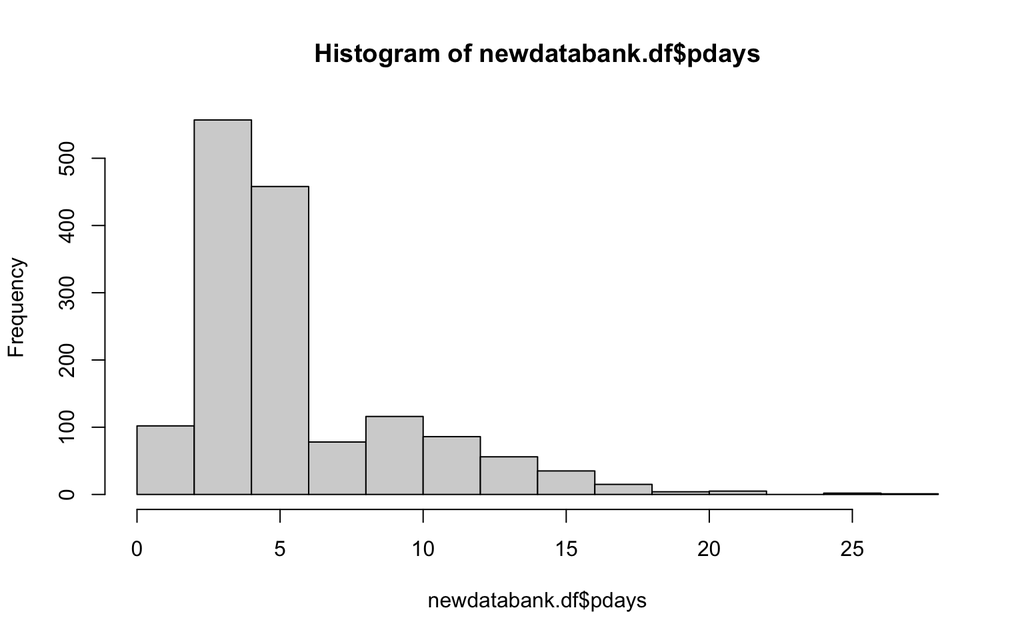

```r
library(tidyr)
newdatabank.df <- newdatabank.df %>% drop_na()
hist(newdatabank.df$pdays)
```

**5-** In this section characteristic values got transformed into numeric values as asked.

```r
a <- 1
newdatabank.df["education"][newdatabank.df["education"] == "illiterate"] <- 0
newdatabank.df["education"][newdatabank.df["education"] == "basic.4y"] <- 4
newdatabank.df["education"][newdatabank.df["education"] == "basic.6y"] <- 6
newdatabank.df["education"][newdatabank.df["education"] == "basic.9y"] <- 9
newdatabank.df["education"][newdatabank.df["education"] == "high.school"] <- 12
newdatabank.df["education"][newdatabank.df["education"] == "professional.course"] <- 12 ^ a
newdatabank.df["education"][newdatabank.df["education"] == "university.degree"] <- 16
newdatabank.df["education"][newdatabank.df["education"] == "unknown"] <- NA
newdatabank.df$education <- as.numeric(newdatabank.df$education)
summary(newdatabank.df)
```

```
##       age          education        previous         pdays
##  Min.   :17.00   Min.   : 0.00   Min.   :1.000   Min.   : 0.000
##  1st Qu.:30.00   1st Qu.:12.00   1st Qu.:1.000   1st Qu.: 3.000
##  Median :37.00   Median :12.00   Median :1.000   Median : 6.000
##  Mean   :41.85   Mean   :12.39   Mean   :1.661   Mean   : 6.015
##  3rd Qu.:52.00   3rd Qu.:16.00   3rd Qu.:2.000   3rd Qu.: 7.000
##  Max.   :98.00   Max.   :16.00   Max.   :7.000   Max.   :27.000
##                  NA's   :98
##       y
##  Length:1515
##  Class :character
##  Mode  :character
##
##
##
##
```

**6-** Using mean, median functions we got the results. For calculating mode of the data we should first create a function for it and use it. Function getmode created to calculate the mode. Then, I plotted the boxplot and the 5 number derived from it are as follows: Min = 17 , 1st Quantile = 30, Median = 37, 3rd Quantile = 52. Also, we could use the summary function to find all these statistics.

```r
library(ggplot2)
AGE <- newdatabank.df$age
mean(AGE)
```

```
## [1] 41.85281
```

```r
median(AGE)
```

```
## [1] 37
```

```r
getmode <- function(v) {
   uniqv <- unique(v)
   uniqv[which.max(tabulate(match(v, uniqv)))]
}
getmode(AGE)
```

```
## [1] 29
```

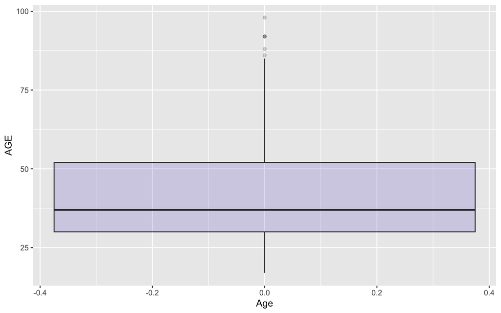

```r
ggplot(newdatabank.df, aes(y=AGE)) +
    geom_boxplot(fill="slateblue", alpha=0.2) +
    xlab("Age")
```

```r
summary(AGE)
```

```
##    Min. 1st Qu.  Median    Mean 3rd Qu.    Max.
##   17.00   30.00   37.00   41.85   52.00   98.00
```

And Here is the quantile plot.

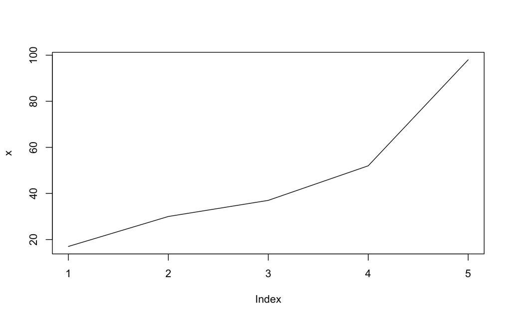

```r
library(ggplot2)
x <- quantile(AGE)
plot(x, type = "l")
```

**7-** In this stage, I normalized the age column using the z-score standardization and assigned it to the age_z variable.

```r
age_z <- (AGE - mean(AGE)) / sd(AGE)
```

**8-** In this stage we detect outliers. While analyzing an standard normal variable, values bigger than 3 and smaller than -3 consider as outliers. In this case, we have 5 outliers.

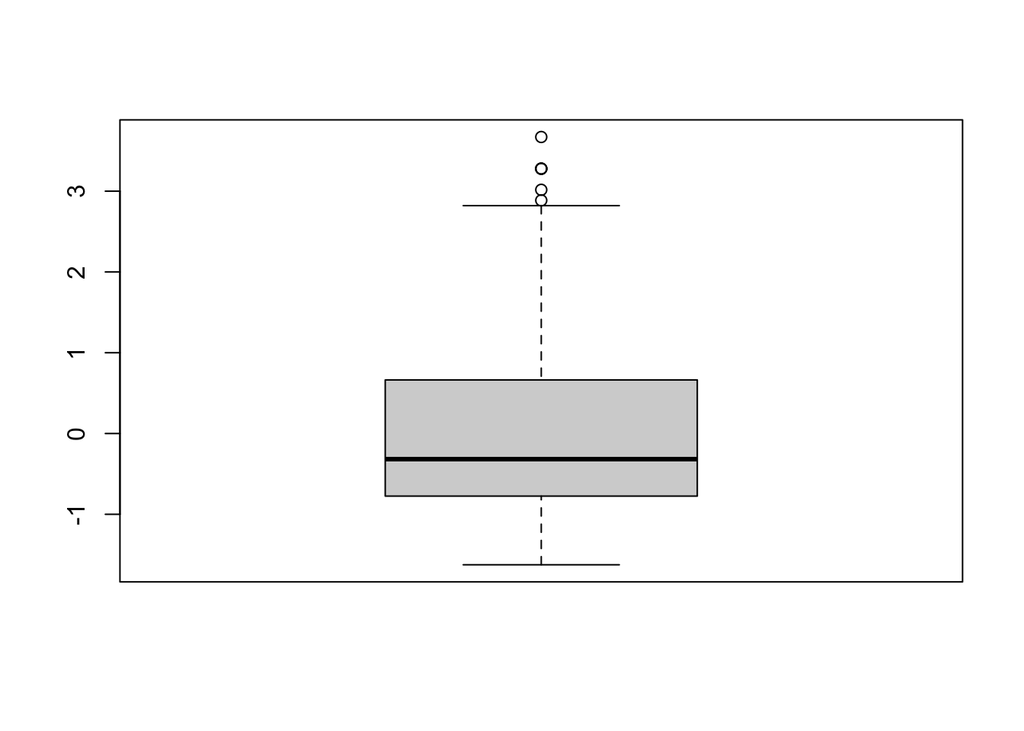

```r
age_z <- as.data.frame(age_z)
#head(age_z)
boxplot(age_z)
```

```r
#remove(age_z_out)
(age_z_out <- age_z$age_z[age_z$age_z > 3 | age_z$age_z < -3])
```

```
## [1] 3.016923 3.670684 3.278427 3.278427 3.278427
```

Also, to show which rows contain this outliers I used the following code. As there were 5 outliers with more than 3 z-score, I can sort the values by the age column and the 5 values that have the highest age are the outliers.

```r
library(dplyr)
df2 <- newdatabank.df %>% arrange(desc(age))
df2[1:5,]
```

```
##   age education previous pdays   y
## 1  98         4        2     2 yes
## 2  92        NA        2     6  no
## 3  92        NA        1     3 yes
## 4  92        NA        4     3 yes
## 5  88         4        1     6 yes
```